# 3.4 HW – Data Manipulations

Submission: Completed qmd file and rendered html file via Canvas.

What will be looked at for grading: Correct code, output and sufficient write-ups where indicated.

## Overview

This problem ties together concepts and functions from all the previous R notes for a comprehensive data analysis problem.

We will be working with hypothetical student grade data `data-grades.csv`, which contains information on two test scores from students of multiple sections for a single professor, and enrollment data `data-majors.csv`, which has the students major.

| ID | Student | Test_1 | Test_2 |
| --- | --- | --- | --- |
| 1381 | LZ-1 | 20 | 55 |
| 2027 | KO-1 | 30 | 40 |
| 6077 | DD-1 | 28 | 68 |
| 6869 | IG-2 | 14 | 42 |
| 4171 | VS-1 | 28 | 50 |

| ID | Major |
| --- | --- |
| 9810 | Physics |
| 9718 | Physics |
| 9685 | Chemisty |
| 9618 | Chemisty |
| 9520 | Physics |

This assignment will take you through steps to clean, organize and analyze these the test scores.

## Assignment

The goal of this assignment is to demonstrate common data manipulation tasks using packages from the **tidyverse**.

### Part a – Data manipulations

The goal is to have a single dataset with the following columns:

- `ID`
- `Student`: just two initials
- `Major`
- `Class`: 1 or 2
- `Test_1`: % out of 100
- `Test_2`: % out of 100
1. For the grades data, we need to split the current student column into two variables, one of their initials and one for the class they are in. Use `tidyr::separate_wider_delim()` to do so.
2. Convert the test scores to percentages (Test 1 is out of 30 points and Test 2 is out of 70 points).
3. Combine grades data and majors data and then sort alphabetically by student initials within each class.

### Part b – Visualize data

Now that the data is cleaned and organized, lets visualize the Test 1 scores to start with.

Create two polished plots to visualize Test 1 scores, at least one of which should include a class comparison or major comparison.

### Part c – Summarize data

Now that we have an idea of the distributions for Test 1, let’s summarize them, specifically we want to create an overall summary and a summary by class.

1. Create a test 1 dataset that contains only the Class, Student initials and Test 1 score.
2. Create an object named `data_summary_overall` that summarizes Test 1 scores with the sample size, average and standard deviation. Then pipe the following lines of code to the end of your summary function call to add an indicator column and rearrange the columns.

```r
data_summary_overall <- < summary function call > %>%
  mutate(Class = "Overall") %>%
  select(4, 1:3)
```

| Class | n | avg | sd |
| --- | --- | --- | --- |
| Overall | 65 | 67.4 | 20.3 |

3. Create another object called `data_summary_section` that performs the same summary functions the previous step, except by Class.

| Class | n | avg | sd |
| --- | --- | --- | --- |
| 1 | 39 | 69.8 | 18.4 |
| 2 | 26 | 63.8 | 22.6 |

4. Combine the overall summary with the class summary rowwise.

### Part d – More manipulations and visualizations 1

If we want to visualize both tests and class at the same time, some more data restructuring is necessary. Specifically, we need the data to have the following columns:

- `ID`
- `Student`: just two initials
- `Major`
- `Class`: 1 or 2
- `Test`: 1 or 2
- `Grade`: % out of 100

Thus, there is two rows per student, one for each test grade.

Perform the necessary data steps and then recreate the following visual. Note that to have the labels for Test 1 and Test 2 nicely formatted, the values need to be cleaned in the data.

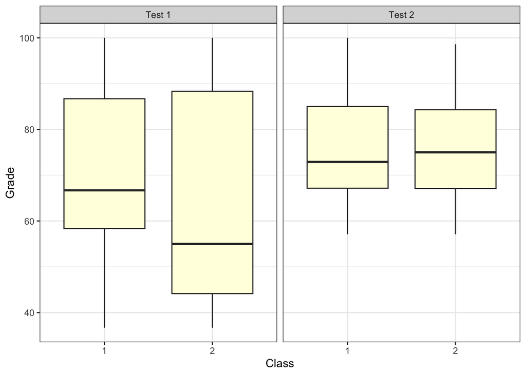

### Part e – More manipulations and visualizations 2

1. Using the Test 1 data from Part c, create a new dataset that also contains curved grades for Test 1 according to the following scheme:
- Class 1 receives 3 additional percentage points (e.g. a 70% becomes a 73%).
- Class 2 receives a 30% of their missed points back (e.g. a 70% becomes a 79%; *HINT: On paper work out an algebra function that accomplishes this and spot check a few values to make sure they are correct*).

*HINT: Use `case_when()`.*

2. Using the curved data, perform the necessary data steps and then recreate the following visual, which compares the original and curved grades for each class.

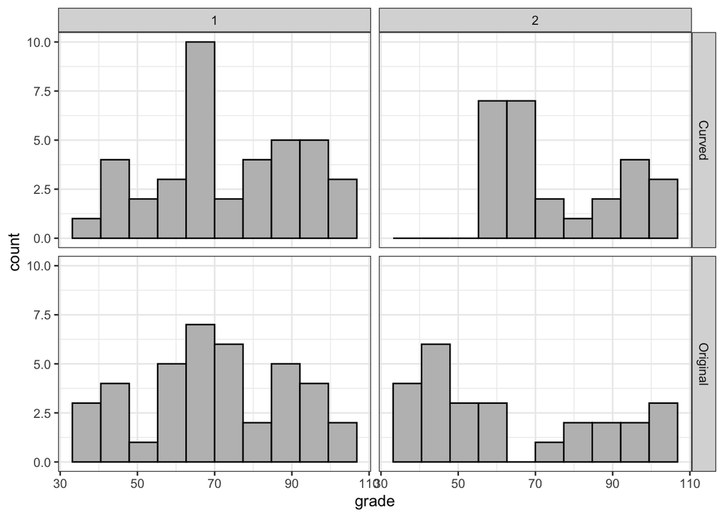